# Aggregating Anteaters Project

2023-11-16

# 1 Data Preparation

Before exploring the sample, initial checks were conducted to ensure that all observations were entered within their possible ranges (for continuous variables) or levels (for categorical variables). We excluded these along with any observation containing missing data (N<sub>excluded</sub> = 5). Table A1 provides an overview of excluded data points and the reason for exclusion. Additionally, the spelling of “Apple” was corrected in the operating system entry of 7 observations from “Appple”. The marginal distributions and relationships amongst variables are visualised in Figure 1 (Figure A1 shows the same plots for pre-processed data).

**Figure 1**  
*Marginal distributions and between-variable relationships*

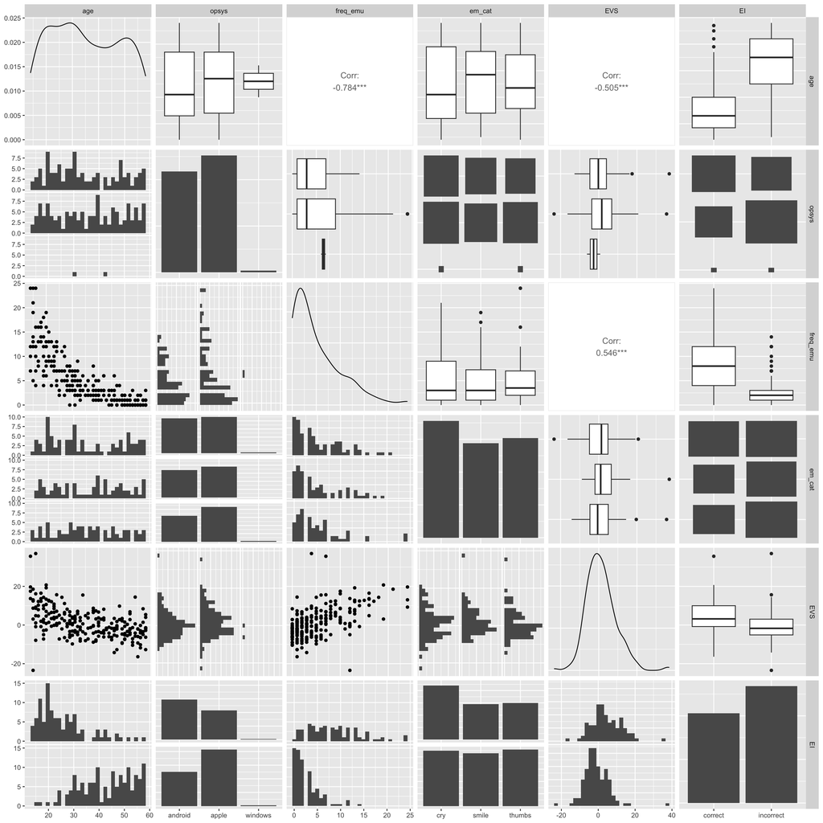